# Trabalho de ECDB G6

## Verificacao da Estrutura dos Dados

```r
cat("Genes:    ", nrow(data_tcga), "\n")
```

```
## Genes:     60660
```

```r
cat("Amostras: ", ncol(data_tcga), "\n")
```

```
## Amostras:  300
```

```r
# Classes dos campos dos metadados clinicos
unlist(lapply(clinical[, 1:15], class))
```

```
##                project.project_id                     cases.case_id
##                       "character"                       "character"
##                cases.consent_type             cases.days_to_consent
##                       "character"                         "integer"
##    cases.days_to_lost_to_followup                cases.disease_type
##                         "logical"                       "character"
##                  cases.index_date            cases.lost_to_followup
##                       "character"                       "character"
##                cases.primary_site                cases.submitter_id
##                       "character"                       "character"
##          demographic.age_at_index     demographic.age_is_obfuscated
##                         "integer"                       "character"
##        demographic.cause_of_death demographic.cause_of_death_source
##                         "logical"                         "logical"
##      demographic.country_of_birth
##                         "logical"
```

```r
# Primeiros registos
head(clinical[, 1:10])
```

```
##    project.project_id                        cases.case_id cases.consent_type
## 1           TCGA-BRCA 001cef41-ff86-4d3f-a140-a647ac4b10a1   Informed Consent
## 4           TCGA-BRCA 0045349c-69d9-4306-a403-c9c1fa836644   Informed Consent
## 5           TCGA-BRCA 00807dae-9f4a-4fd1-aac2-82eb11bf2afb   Informed Consent
## 12          TCGA-BRCA 00a2d166-78c9-4687-a195-3d6315c27574   Informed Consent
## 15          TCGA-BRCA 00b11ca8-8540-4a3d-b602-ec754b00230b   Informed Consent
## 23          TCGA-BRCA 011b9b2d-ebe5-42bf-9662-d922faccc7a1   Informed Consent
##    cases.days_to_consent cases.days_to_lost_to_followup
## 1                    -34                             NA
## 4                     76                             NA
## 5                     19                             NA
## 12                     0                             NA
## 15                    11                             NA
## 23                    16                             NA
##                      cases.disease_type cases.index_date cases.lost_to_followup
## 1          Ductal and Lobular Neoplasms        Diagnosis                   <NA>
## 4          Adenomas and Adenocarcinomas        Diagnosis                   <NA>
## 5  Adnexal and Skin Appendage Neoplasms        Diagnosis                     No
## 12         Ductal and Lobular Neoplasms        Diagnosis                    Yes
## 15         Ductal and Lobular Neoplasms        Diagnosis                     No
## 23         Ductal and Lobular Neoplasms        Diagnosis                     No
##    cases.primary_site cases.submitter_id
## 1              Breast       TCGA-E2-A1IU
## 4              Breast       TCGA-A1-A0SB
## 5              Breast       TCGA-A2-A04W
## 12             Breast       TCGA-AN-A0AM
## 15             Breast       TCGA-LL-A440
## 23             Breast       TCGA-A7-A26E
```

```r
# Nomes dos campos
names(clinical)[1:20]
```

```
##  [1] "project.project_id"
##  [2] "cases.case_id"
##  [3] "cases.consent_type"
##  [4] "cases.days_to_consent"
##  [5] "cases.days_to_lost_to_followup"
##  [6] "cases.disease_type"
##  [7] "cases.index_date"
##  [8] "cases.lost_to_followup"
##  [9] "cases.primary_site"
## [10] "cases.submitter_id"
## [11] "demographic.age_at_index"
## [12] "demographic.age_is_obfuscated"
## [13] "demographic.cause_of_death"
## [14] "demographic.cause_of_death_source"
## [15] "demographic.country_of_birth"
## [16] "demographic.country_of_residence_at_enrollment"
## [17] "demographic.days_to_birth"
## [18] "demographic.days_to_death"
## [19] "demographic.demographic_id"
## [20] "demographic.education_level"
```

```r
# Tipos de amostra disponíveis
meta <- colData(data_tcga)
print(table(meta$sample_type))
```

```
##
##       Primary Tumor Solid Tissue Normal
##                 271                  29
```

## Tratamento de Valores Omissos

```r
# Contagem de NAs por coluna nos metadados clinicos
na_counts         <- sapply(clinical, function(x) sum(is.na(x)))
na_counts_nonzero <- na_counts[na_counts > 0]

cat("Colunas com valores omissos:", length(na_counts_nonzero), "\n")
```

```
## Colunas com valores omissos: 196
```

```r
head(sort(na_counts_nonzero, decreasing = TRUE), 20)
```

```
##             cases.days_to_lost_to_followup
##                                       1098
##                 demographic.cause_of_death
##                                       1098
##          demographic.cause_of_death_source
##                                       1098
##               demographic.country_of_birth
##                                       1098
##                demographic.education_level
##                                       1098
##                 demographic.marital_status
##                                       1098
##      demographic.occupation_duration_years
##                                       1098
##               demographic.population_group
##                                       1098
##                  demographic.year_of_death
##                                       1098
##                  diagnoses.adrenal_hormone
##                                       1098
##                  diagnoses.ajcc_clinical_m
##                                       1098
##                  diagnoses.ajcc_clinical_n
##                                       1098
##              diagnoses.ajcc_clinical_stage
##                                       1098
##                  diagnoses.ajcc_clinical_t
##                                       1098
##         diagnoses.ajcc_serum_tumor_markers
##                                       1098
##             diagnoses.ann_arbor_b_symptoms
##                                       1098
##   diagnoses.ann_arbor_b_symptoms_described
##                                       1098
##         diagnoses.ann_arbor_clinical_stage
##                                       1098
## diagnoses.ann_arbor_extranodal_involvement
##                                       1098
##       diagnoses.ann_arbor_pathologic_stage
##                                       1098
```

```r
cat("\nLinhas sem NAs (complete cases):", sum(complete.cases(clinical)), "\n")
```

```
##
## Linhas sem NAs (complete cases): 0
```

```r
cat("Total de linhas:               ", nrow(clinical), "\n")
```

```
## Total de linhas:                1098
```

```r
# NAs na matriz de contagens
counts_raw <- assay(data_tcga, "unstranded")
cat("\nNAs na matriz de contagens:", sum(is.na(counts_raw)), "\n")
```

```
##
## NAs na matriz de contagens: 0
```

## Filtragem de Genes com Expressao Baixa

```r
counts_raw <- assay(data_tcga, "unstranded")

# Calcular CPM
myCPM <- cpm(counts_raw)

# Criterio: CPM > 0.5 em pelo menos 2 amostras
thresh          <- myCPM > 0.5
keep            <- rowSums(thresh) >= 2
counts_filtered <- counts_raw[keep, ]

cat("Genes antes da filtragem: ", nrow(counts_raw), "\n")
```

```
## Genes antes da filtragem:  60660
```

```r
cat("Genes apos filtragem:     ", nrow(counts_filtered), "\n")
```

```
## Genes apos filtragem:      33913
```

```r
cat("Genes removidos:          ", nrow(counts_raw) - nrow(counts_filtered), "\n")
```

```
## Genes removidos:           26747
```

```r
summary(keep)
```

```
##    Mode   FALSE    TRUE
## logical   26747   33913
```

## Normalizacao (TMM) e Standardizacao

```r
# Criar objeto DGEList
dgeObj <- DGEList(counts_filtered)

# Calcular factores de normalizacao TMM (corrige composition bias)
dgeObj <- calcNormFactors(dgeObj)

# Verificar factores
head(dgeObj$samples)
```

```
##                              group lib.size norm.factors
## TCGA-GM-A3XN-01A-12R-A22U-07     1 61240772    1.1850364
## TCGA-A8-A08A-01A-11R-A32Y-07     1 56206486    0.9941120
## TCGA-A2-A0T2-01A-11R-A084-07     1 53537977    0.8332251
## TCGA-A2-A0EO-01A-11R-A034-07     1 63546315    0.8856998
## TCGA-A8-A081-01A-11R-A00Z-07     1 75358318    1.0771455
## TCGA-A2-A3KC-01A-11R-A213-07     1 53998056    1.1686795
```

```r
# Gerar log-CPM normalizado
logcounts <- cpm(dgeObj, log = TRUE)
cat("Dimensoes logCPM normalizado:", dim(logcounts), "\n")
```

```
## Dimensoes logCPM normalizado: 33913 300
```

```r
# Standardizacao (z-score por gene)
# Subtrai a media e divide pelo desvio padrao de cada gene
logcounts_scaled <- t(scale(t(logcounts)))

cat("Media apos standardizacao (esperado ~0):  ", round(mean(logcounts_scaled), 4), "\n")
```

```
## Media apos standardizacao (esperado ~0):   0
```

```r
cat("DesvPad apos standardizacao (esperado ~1):", round(sd(logcounts_scaled), 4), "\n")
```

```
## DesvPad apos standardizacao (esperado ~1): 0.9983
```

## Exportar Dados Processados

```r
if (exists("counts_filtered")) {
  write.csv(as.data.frame(counts_filtered), file = "counts_filtered.csv")
  cat("counts_filtered.csv exportado\n")
}
```

```
## counts_filtered.csv exportado
```

```r
if (exists("logcounts")) {
  write.csv(as.data.frame(logcounts), file = "logcounts_normalized.csv")
  cat("logcounts_normalized.csv exportado\n")
}
```

```
## logcounts_normalized.csv exportado
```

```r
if (exists("logcounts_scaled")) {
  write.csv(as.data.frame(logcounts_scaled), file = "logcounts_scaled.csv")
  cat("logcounts_scaled.csv exportado\n")
}
```

```
## logcounts_scaled.csv exportado
```

```r
if (exists("clinical")) {
  write.csv(clinical, file = "clinical_processed.csv")
  cat("clinical_processed.csv exportado\n")
}
```

```
## clinical_processed.csv exportado
```

```r
# sumarização + expressão diferencial
logcounts        <- read.csv("logcounts_normalized.csv", row.names = 1)
counts_filtered  <- read.csv("counts_filtered.csv", row.names = 1)
clinical         <- read.csv("clinical_processed.csv", row.names = 1)

# clustering + redução de dimensionalidade
logcounts_scaled <- read.csv("logcounts_scaled.csv", row.names = 1)
clinical         <- read.csv("clinical_processed.csv", row.names = 1)

#Machine learning
logcounts        <- read.csv("logcounts_normalized.csv", row.names = 1)
clinical         <- read.csv("clinical_processed.csv", row.names = 1)
```

# Sumarisação dos Dados

## Verificar o nome dos campos

```r
cat("Verificar o nome dos campos\n\n")
```

```
## Verificar o nome dos campos
```

```r
cat("logcounts:\n")
```

```
## logcounts:
```

```r
names(logcounts)
```

```r
cat("\n\ncounts_filtered:\n")
```

```
##
##
## counts_filtered:
```

```r
names(counts_filtered)
```

```r
cat("\n\nclinical:\n")
```

```
##
##
## clinical:
```

```r
names(clinical)
```

```
##   [1] "project.project_id"
##   [2] "cases.case_id"
##   [3] "cases.consent_type"
##   [4] "cases.days_to_consent"
##   [5] "cases.days_to_lost_to_followup"
##   [6] "cases.disease_type"
##   [7] "cases.index_date"
##   [8] "cases.lost_to_followup"
##   [9] "cases.primary_site"
##  [10] "cases.submitter_id"
##  [11] "demographic.age_at_index"
##  [12] "demographic.age_is_obfuscated"
##  [13] "demographic.cause_of_death"
##  [14] "demographic.cause_of_death_source"
##  [15] "demographic.country_of_birth"
```

[output cut: 186 more lines]

```r
cat("\n\nlogcounts_scaled:\n")
```

```
##
##
## logcounts_scaled:
```

```r
names(logcounts_scaled)
```

## Verificar dimensões dos dados

```r
cat("Verificar dimensões dos dados\n\n")
```

```
## Verificar dimensões dos dados
```

```r
cat("logcounts:\n")
```

```
## logcounts:
```

```r
dim(logcounts)
```

```
## [1] 33913   300
```

```r
cat("\ncounts_filtered:\n")
```

```
##
## counts_filtered:
```

```r
dim(counts_filtered)
```

```
## [1] 33913   300
```

```r
cat("\nclinical:\n")
```

```
##
## clinical:
```

```r
dim(clinical)
```

```
## [1] 1098  201
```

```r
cat("\nlogcounts_scaled:\n")
```

```
##
## logcounts_scaled:
```

```r
dim(logcounts_scaled)
```

```
## [1] 33913   300
```

## Verificar estrutura dos dados

```r
cat("Verificar estrutura dos dados\n\n")
```

```
## Verificar estrutura dos dados
```

```r
cat("logcounts:\n")
```

```
## logcounts:
```

```r
#sapply(logcounts, class)
str(logcounts)
```

```
##  num [1:33913, 1:300] 5.04 2.68 4.66 4.34 3 ...
##  - attr(*, "dimnames")=List of 2
##   ..$ : chr [1:33913] "ENSG00000000003.15" "ENSG00000000005.6" "ENSG00000000419.13" "ENSG00000000457.14" ...
##   ..$ : chr [1:300] "TCGA-GM-A3XN-01A-12R-A22U-07" "TCGA-A8-A08A-01A-11R-A32Y-07" "TCGA-A2-A0T2-01A-11R-A084-07" "TCGA-A2-A0EO-01A-11R-A034-07" ...
```

```r
cat("\ncounts_filtered:\n")
```

```
##
## counts_filtered:
```

```r
#sapply(counts_filtered, class)
str(counts_filtered)
```

```
##  int [1:33913, 1:300] 2380 461 1838 1465 580 1253 5112 1465 1635 1630 ...
##  - attr(*, "dimnames")=List of 2
##   ..$ : chr [1:33913] "ENSG00000000003.15" "ENSG00000000005.6" "ENSG00000000419.13" "ENSG00000000457.14" ...
##   ..$ : chr [1:300] "TCGA-GM-A3XN-01A-12R-A22U-07" "TCGA-A8-A08A-01A-11R-A32Y-07" "TCGA-A2-A0T2-01A-11R-A084-07" "TCGA-A2-A0EO-01A-11R-A034-07" ...
```

```r
cat("\nclinical:\n")
```

```
##
## clinical:
```

```r
#sapply(clinical, class)
str(clinical)
```

```
## 'data.frame':    1098 obs. of  201 variables:
##  $ project.project_id                                : chr  "TCGA-BRCA" "TCGA-BRCA" "TCGA-BRCA" "TCGA-BRCA" ...
##  $ cases.case_id                                     : chr  "001cef41-ff86-4d3f-a140-a647ac4b10a1" "0045349c-69d9-4306-a403-c9c1fa836644" "00807dae-9f4a-4fd1-aac2-82eb11bf2afb" "00a2d166-78c9-4687-a195-3d6315c27574" ...
##  $ cases.consent_type                                : chr  "Informed Consent" "Informed Consent" "Informed Consent" "Informed Consent" ...
##  $ cases.days_to_consent                             : int  -34 76 19 0 11 16 31 36 13 5 ...
##  $ cases.days_to_lost_to_followup                    : logi  NA NA NA NA NA NA ...
##  $ cases.disease_type                                : chr  "Ductal and Lobular Neoplasms" "Adenomas and Adenocarcinomas" "Adnexal and Skin Appendage Neoplasms" "Ductal and Lobular Neoplasms" ...
##  $ cases.index_date                                  : chr  "Diagnosis" "Diagnosis" "Diagnosis" "Diagnosis" ...
##  $ cases.lost_to_followup                            : chr  NA NA "No" "Yes" ...
##  $ cases.primary_site                                : chr  "Breast" "Breast" "Breast" "Breast" ...
##  $ cases.submitter_id                                : chr  "TCGA-E2-A1IU" "TCGA-A1-A0SB" "TCGA-A2-A04W" "TCGA-AN-A0AM" ...
##  $ demographic.age_at_index                          : int  60 70 50 56 61 71 76 74 59 61 ...
##  $ demographic.age_is_obfuscated                     : chr  "false" "false" "false" "false" ...
##  $ demographic.cause_of_death                        : logi  NA NA NA NA NA NA ...
##  $ demographic.cause_of_death_source                 : logi  NA NA NA NA NA NA ...
```

[output cut: 86 more lines]

```r
cat("\nlogcounts_scaled:\n")
```

```
##
## logcounts_scaled:
```

```r
#sapply(logcounts_scaled, class)
str(logcounts_scaled)
```

```
##  num [1:33913, 1:300] -0.314 1.788 -0.92 -0.577 -0.383 ...
##  - attr(*, "dimnames")=List of 2
##   ..$ : chr [1:33913] "ENSG00000000003.15" "ENSG00000000005.6" "ENSG00000000419.13" "ENSG00000000457.14" ...
##   ..$ : chr [1:300] "TCGA-GM-A3XN-01A-12R-A22U-07" "TCGA-A8-A08A-01A-11R-A32Y-07" "TCGA-A2-A0T2-01A-11R-A084-07" "TCGA-A2-A0EO-01A-11R-A034-07" ...
##  - attr(*, "scaled:center")= Named num [1:33913] 5.36 -1.54 5.23 4.68 3.31 ...
##   ..- attr(*, "names")= chr [1:33913] "ENSG00000000003.15" "ENSG00000000005.6" "ENSG00000000419.13" "ENSG00000000457.14" ...
##  - attr(*, "scaled:scale")= Named num [1:33913] 1.026 2.359 0.617 0.588 0.787 ...
##   ..- attr(*, "names")= chr [1:33913] "ENSG00000000003.15" "ENSG00000000005.6" "ENSG00000000419.13" "ENSG00000000457.14" ...
```

# Analise das Dados

As três variáveis “counts_filtered”, “logcounts” e “logcounts_scaled” não tiveram uma estatística descritiva convencional (sumário e desvio padrão), pois contêm milhares de genes. A apresentação de média, mediana ou desvio padrão para cada gene individual não seria informativa nem legível neste relatório. Em vez disso, procedeu-se à visualização global da distribuição de expressão e análise dos genes expressos.

## counts_filtered

Os dados em counts_filtered não passaram por qualquer transformação, a qual é essencial para permitir uma análise adequada da expressão gênica. Por isso, a análise direta destes dados é pouco informativa e não foi realizada

## Logcounts

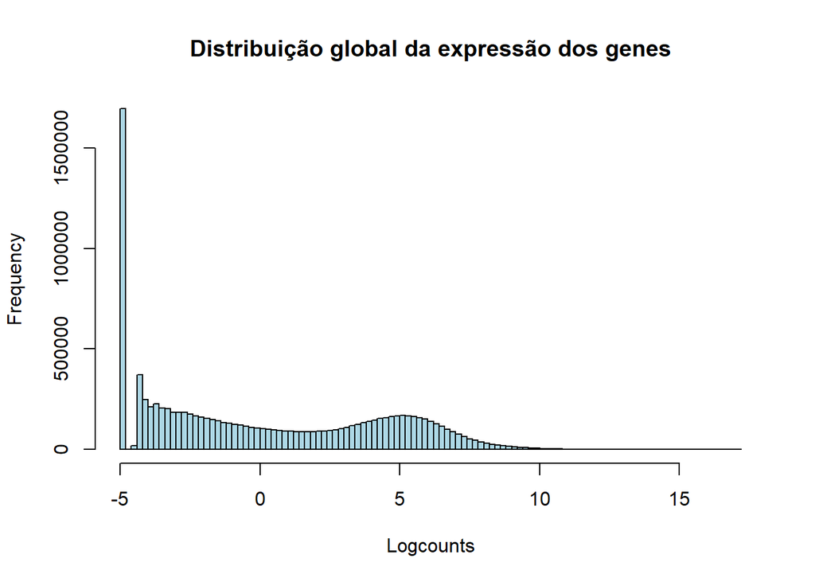

```r
hist(as.numeric(as.matrix(logcounts)),
     breaks=100,
     col="lightblue",
     main="Distribuição global da expressão dos genes",
     xlab="Logcounts")
```

```r
# calcular média por gene
medias_log_genes <- rowMeans(logcounts)
medias_log_genes_df <- data.frame(
  Gene = names(medias_log_genes),
  MeanExpression = medias_log_genes
)
```

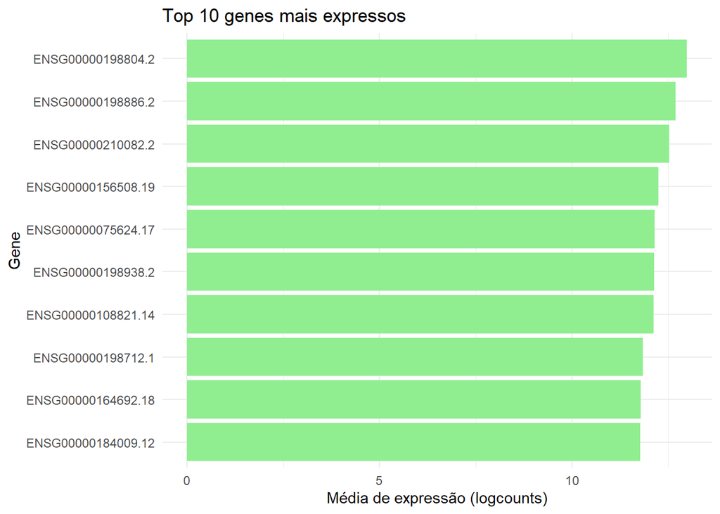

```r
Logcounts_top10 <- medias_log_genes_df[order(-medias_log_genes_df$MeanExpression), ][1:10, ]

ggplot(Logcounts_top10, aes(x=reorder(Gene, MeanExpression), y=MeanExpression)) +
  geom_bar(stat="identity", fill="lightgreen") +
  coord_flip() +
  theme_minimal() +
  ylab("Média de expressão (logcounts)") +
  xlab("Gene") +
  ggtitle("Top 10 genes mais expressos")
```

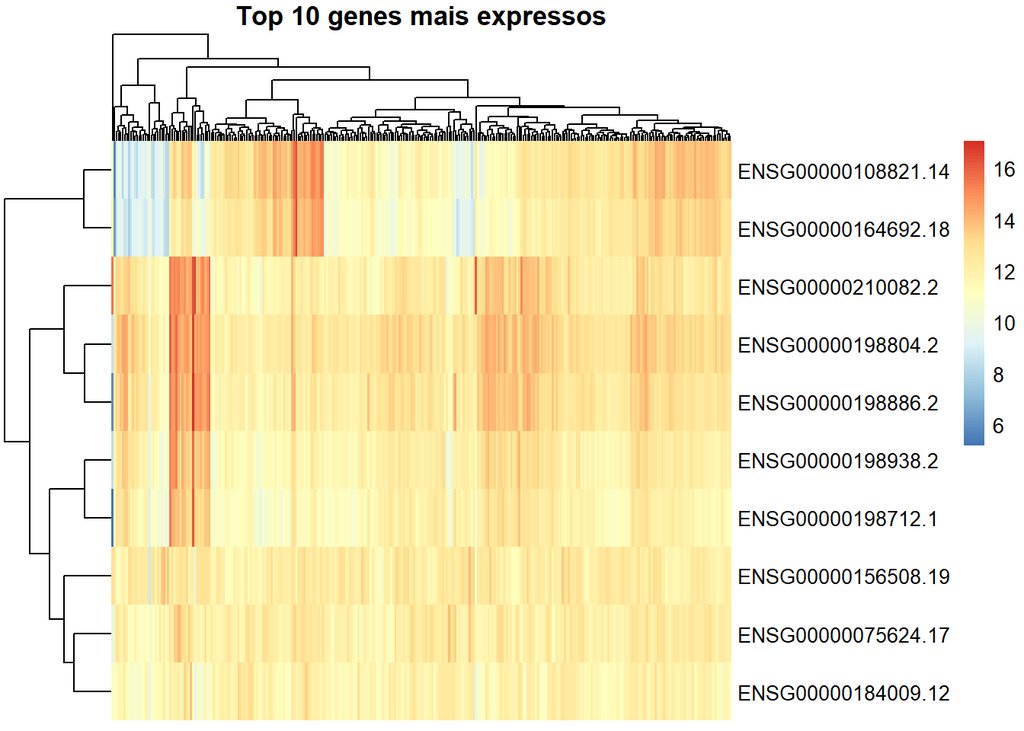

```r
Logcounts_top_genes <- names(sort(rowMeans(logcounts), decreasing = TRUE))[1:10]

pheatmap(logcounts[Logcounts_top_genes, ],
         cluster_rows = TRUE,
         cluster_cols = TRUE,
         show_rownames = TRUE,
         show_colnames = FALSE,
         main = "Top 10 genes mais expressos")
```

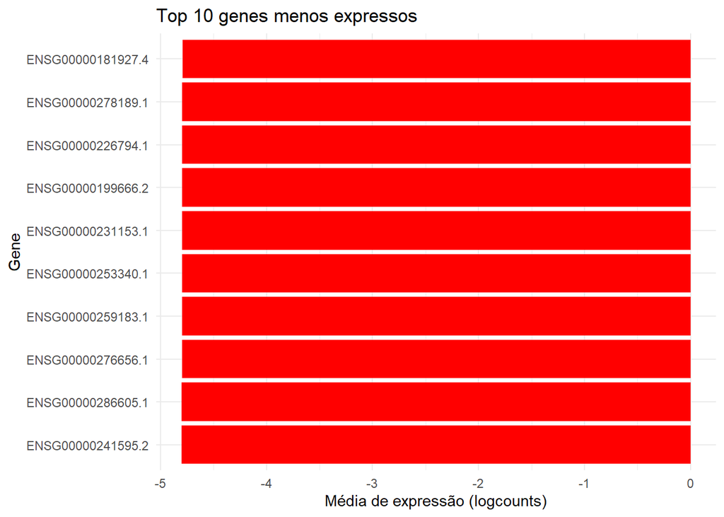

```r
Logcounts_bottom10 <- medias_log_genes_df[order(medias_log_genes_df$MeanExpression), ][1:10, ]

ggplot(Logcounts_bottom10, aes(x=reorder(Gene, MeanExpression), y=MeanExpression)) +
  geom_bar(stat="identity", fill="red") +
  coord_flip() +
  theme_minimal() +
  ylab("Média de expressão (logcounts)") +
  xlab("Gene") +
  ggtitle("Top 10 genes menos expressos")
```

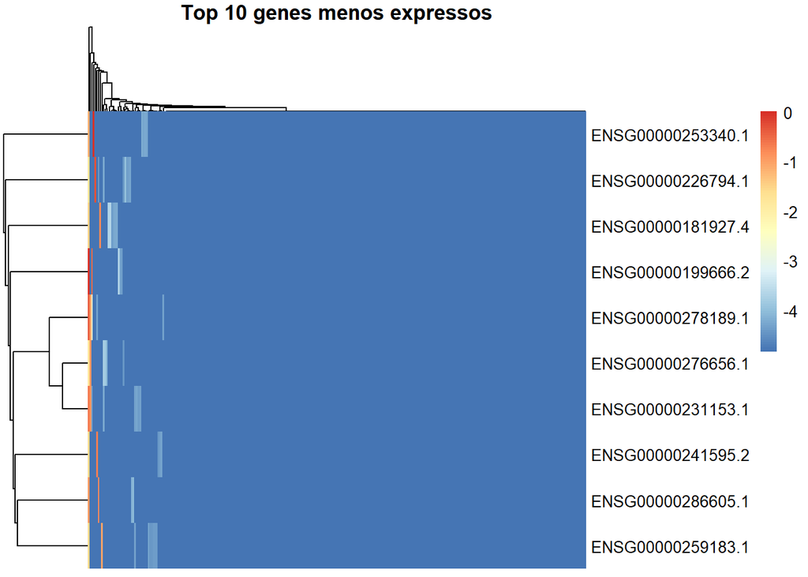

```r
Logcounts_bottom_genes <- names(sort(rowMeans(logcounts), decreasing = FALSE))[1:10]

pheatmap(logcounts[Logcounts_bottom_genes, ],
         cluster_rows = TRUE,
         cluster_cols = TRUE,
         show_rownames = TRUE,
         show_colnames = FALSE,
         main = "Top 10 genes menos expressos")
```

```r
# Variabilidade por gene
gene_sd <- apply(logcounts, 1, sd)

gene_sd_df <- data.frame(
  Gene = names(gene_sd),
  Variability = gene_sd
)
```

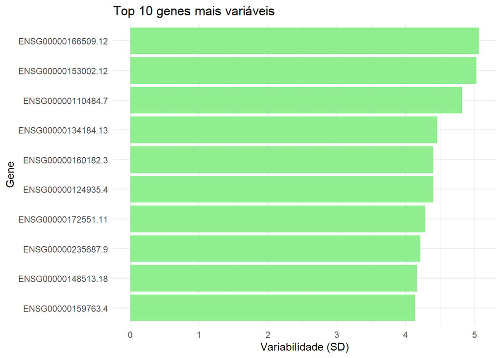

```r
top10_var <- gene_sd_df[order(-gene_sd_df$Variability), ][1:10, ]

ggplot(top10_var, aes(x=reorder(Gene, Variability), y=Variability)) +
  geom_bar(stat="identity", fill="lightgreen") +
  coord_flip() +
  theme_minimal() +
  ylab("Variabilidade (SD)") +
  xlab("Gene") +
  ggtitle("Top 10 genes mais variáveis")
```

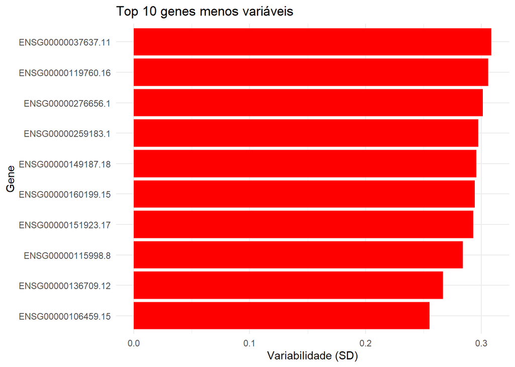

```r
bottom10_var <- gene_sd_df[order(gene_sd_df$Variability), ][1:10, ]

ggplot(bottom10_var, aes(x=reorder(Gene, Variability), y=Variability)) +
  geom_bar(stat="identity", fill="red") +
  coord_flip() +
  theme_minimal() +
  ylab("Variabilidade (SD)") +
  xlab("Gene") +
  ggtitle("Top 10 genes menos variáveis")
```

## logcounts_scaled

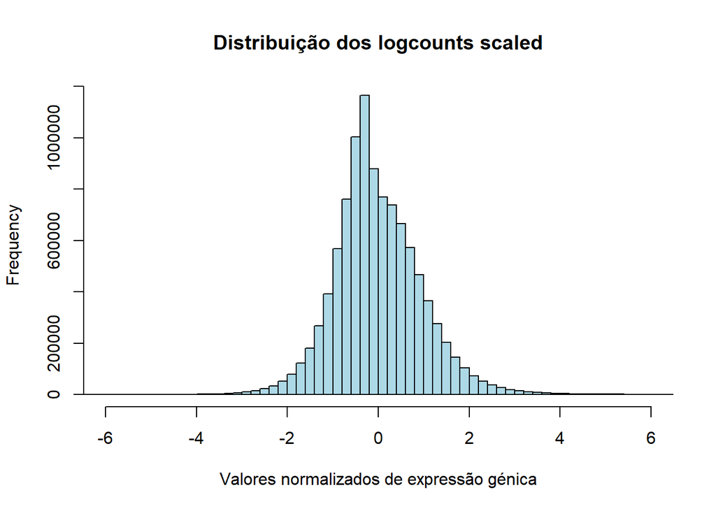

```r
hist(as.numeric(as.matrix(logcounts_scaled)),
     breaks=100,
     col="lightblue",
     main="Distribuição dos logcounts scaled",
     xlab="Valores normalizados de expressão génica",
     xlim=c(-6, 6))
```

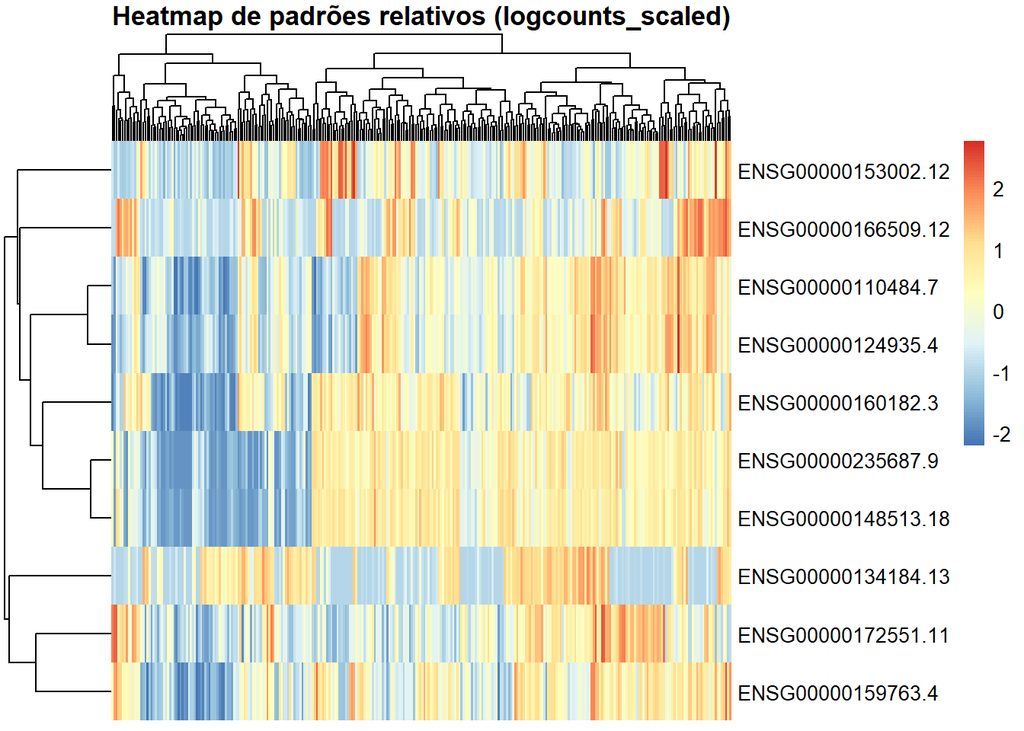

```r
# Como os genes mais variaveis se comportam entre as amostras
# Quais os genes mais variaveis
top_genes_var <- names(sort(apply(logcounts, 1, var), decreasing = TRUE))[1:10]

# heatmap dos genes mais variaveis
pheatmap(logcounts_scaled[top_genes_var, ],
         scale = "none",
         show_rownames = TRUE,
         show_colnames = FALSE,
         main = "Heatmap de padrões relativos (logcounts_scaled)")
```

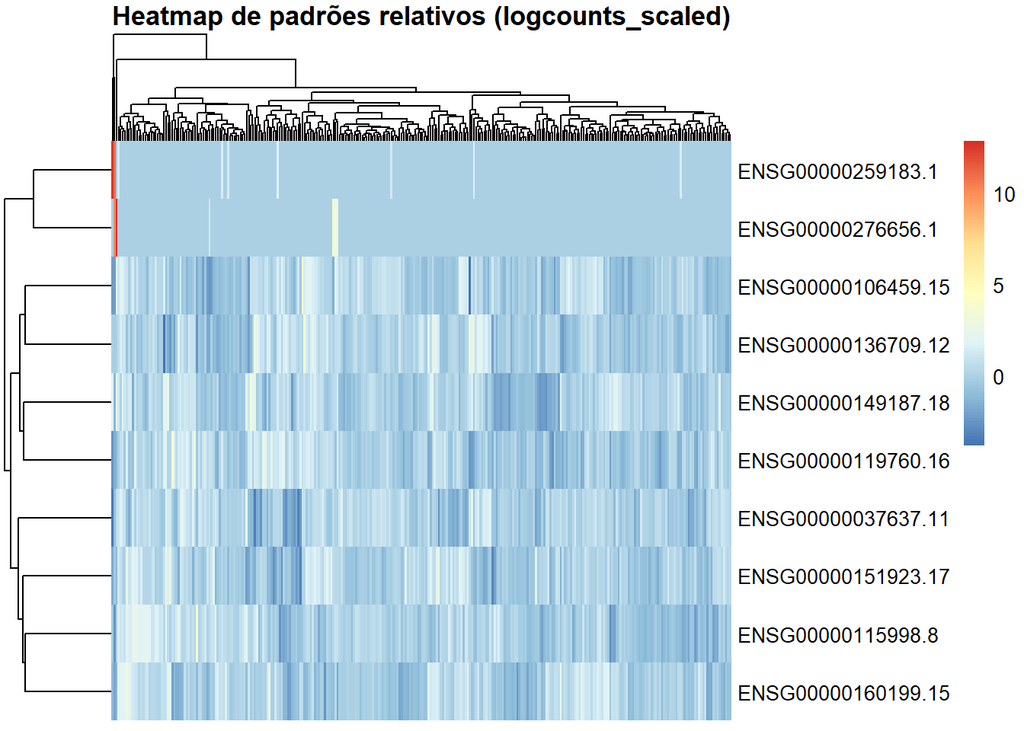

```r
# Como os genes menos variaveis se comportam entre as amostras
# Quais os genes menos variaveis
Bottom_genes_var <- names(sort(apply(logcounts, 1, var), decreasing = FALSE))[1:10]

# heatmap dos genes menos variaveis
pheatmap(logcounts_scaled[Bottom_genes_var, ],
         scale = "none",
         show_rownames = TRUE,
         show_colnames = FALSE,
         main = "Heatmap de padrões relativos (logcounts_scaled)")
```

## Clinical

### estatística descritiva

```r
col_excluir <- c("cases.case_id", "cases.submitter_id", "demographic.demographic_id", "demographic.submitter_id", "diagnoses.diagnosis_id", "diagnoses.submitter_id", "diagnoses.tumor_of_origin", "treatments.submitter_id", "treatments.treatment_id")

clinical_sub <- clinical[, !(names(clinical) %in% col_excluir)]
```

```r
cat("Dimenção de Clinical")
```

```
## Dimenção de Clinical
```

```r
dim(clinical_sub)
```

```
## [1] 1098  192
```

```r
# Identificar colunas numéricas
numericas <- sapply(clinical_sub, is.numeric)

# Sumário das colunas numéricas
cat("Sumário das colunas numéricas")
summary(clinical_sub[, numericas])

# Desvio Padrão das colunas numéricas
cat("Desvio Padrão das colunas numéricas")
sapply(clinical_sub[, numericas], sd, na.rm = TRUE)
```

[output not shown]

```r
# Tabelas das colunas categóricas
categoricas <- !numericas
cat("Tabelas das colunas categóricas")
```

```
## Tabelas das colunas categóricas
```

```r
lapply(clinical_sub[, categoricas], table)
```

```
## $project.project_id
##
## TCGA-BRCA
##      1098
##
## $cases.consent_type
##
## Consent by Death   Consent Waiver Informed Consent
##               41                1             1046
##
## $cases.days_to_lost_to_followup
## < table of extent 0 >
##
## $cases.disease_type
##
##          Adenomas and Adenocarcinomas  Adnexal and Skin Appendage Neoplasms
##                                     3                                     1
##                  Basal Cell Neoplasms          Complex Epithelial Neoplasms
##                                     1                                    14
## Cystic, Mucinous and Serous Neoplasms          Ductal and Lobular Neoplasms
##                                    16                                  1054
##             Epithelial Neoplasms, NOS             Fibroepithelial Neoplasms
##                                     5                                     2
##               Squamous Cell Neoplasms
##                                     2
##
## $cases.index_date
##
## Diagnosis
##      1096
##
## $cases.lost_to_followup
##
##  No Yes
## 552  64
##
## $cases.primary_site
##
## Breast
##   1098
```

[output cut: 851 more lines]

```
##
## $treatments.treatment_type
##
##                Ancillary Treatment             Bisphosphonate Therapy
##                                  2                                  4
##                       Chemotherapy                    Hormone Therapy
##                                250                                122
## Immunotherapy (Including Vaccines)        Pharmaceutical Therapy, NOS
##                                  2                                123
##             Radiation Therapy, NOS           Radiation, External Beam
##                                152                                105
##            Radiation, Radioisotope                       Surgery, NOS
##                                  1                                314
##         Targeted Molecular Therapy
##                                  4
```